# Lab 2 Write-up

Erica Chen

```r
#Import the data
spring_2020_lab_2_data <- read.csv("spring_2020_lab_2_data.csv", header = T)
#Attach the data
attach(spring_2020_lab_2_data)
```

##### Exercise 1: Comparing HLY in Terms of Life Expectancy

```r
cor(avg.life.expectancy,HLY)
```

```
## [1] 0.8749937
```

```r
plot(avg.life.expectancy,HLY, xlab= "Inequality-Adjusted Life Expectancy", ylab= "Happy Life Years", main = "Life Expectancy Affecting Number of Happy Years in Life")


lm(HLY~avg.life.expectancy)
```

```
##
## Call:
## lm(formula = HLY ~ avg.life.expectancy)
##
## Coefficients:
##         (Intercept)  avg.life.expectancy
##             -63.734                1.325
```

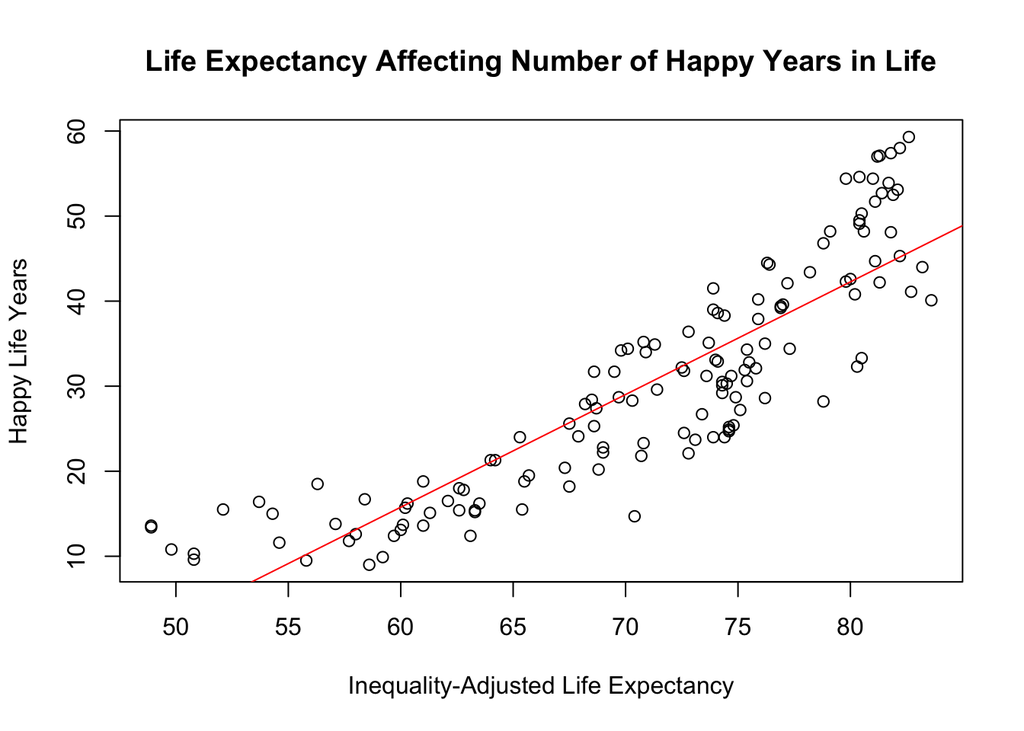

```r
abline(-63.734, 1.325, col="red")
```

The correlation between the two variables presented above display a strong positive relationship. The equation of the regression line, y=-63.734+1.325x, can be used to measure the differences of the actual value to predicted value of the country’s happy life years in terms of inequality adjusted life expectancy.

```r
cor(avg.life.expectancy,HLY)^2
```

```
## [1] 0.765614
```

The regression line acurrately represents the positive relationship between the variables because the coefficient of determination of the model above is 0.766, which is close to 1.

```r
-63.734+1.325*83.2
```

```
## [1] 46.506
```

Comparing the residuals for the United States and a country of my choice, Japan, the residual for Japan’s life expectancy to happy life years is -2.506. The actual number of happy life years is measured to be below the regression line by a small amount.

```r
-63.734+1.325*78.8
```

```
## [1] 40.676
```

The residual for the United State’s life expectancy to happy life years is 6.124. The actual number of happy life years is measured to be above the regression line by a moderate amount

##### Exercise 2: Comparing Ecological Footprint in Terms of GDP per Capita

```r
cor(GDP.per.capita,footprint)
```

```
## [1] 0.7963459
```

```r
plot(GDP.per.capita,footprint, xlab="GDP Per Capita", main="Economic Activity Affecting Ecological Footprint Across All Countries", ylab ="Ecological Footprint (gha/capita)")

lm(footprint~GDP.per.capita)
```

```
##
## Call:
## lm(formula = footprint ~ GDP.per.capita)
##
## Coefficients:
##    (Intercept)  GDP.per.capita
##      1.968e+00       9.288e-05
```

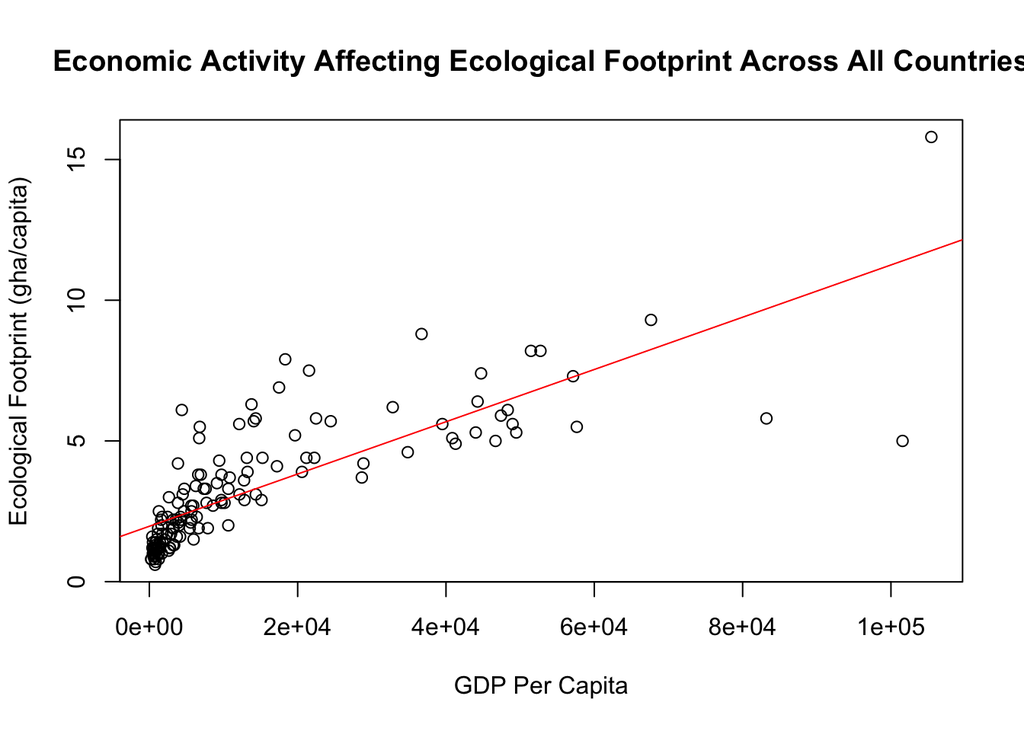

```r
abline(1.968, 9.288e-05, col="red")
```

The GDP per capita to ecological footprint displays a strong positive relationship. This can be represented with the equation y=1.968+9.288e-05x.

```r
cor(GDP.per.capita,footprint)^2
```

```
## [1] 0.6341668
```

In otherwords, $\hat{y}=1.968+9.288e-05x$ is a regression line that best fits the data points above because the coefficient of determination of a model is 0.634. I would consider R^2 to be a weaker representation if it calculates to below 0.5, while our data does not.

```r
1.968+9.288e-05*46679
```

```
## [1] 6.303546
```

```r
1.968+9.288e-05*51457
```

```
## [1] 6.747326
```

##### Exercise 3: Asia Pacific Region

```r
asia.only <-subset(spring_2020_lab_2_data,region== "Asia Pacific")

cor(asia.only$GDP.per.capita,asia.only$footprint)
```

```
## [1] 0.8534438
```

```r
lm(asia.only$footprint~asia.only$GDP.per.capita)
```

```
##
## Call:
## lm(formula = asia.only$footprint ~ asia.only$GDP.per.capita)
##
## Coefficients:
##              (Intercept)  asia.only$GDP.per.capita
##                1.6756987                 0.0001177
```

[figure not shown]

```r
plot(asia.only$GDP.per.capita,asia.only$footprint, ylab ="Ecological Footprint (gha/capita)", xlab = "GDP Per Capita", main = "Economic Activity Affecting Ecological Footprint Across All Countries")

abline(1.6756987,0.0001177, col="red")
```

```r
cor(asia.only$GDP.per.capita,asia.only$footprint)^2
```

```
## [1] 0.7283663
```

The worldwide pattern compared to the Asia Pacific region pattern are similar because both graphs present a strong positive relationship. However, the correlation between countries in the Asia Pacific region show a correlation of 0.853 because the trend line is steeper than the pattern presented in the worldwide data. To show that the regression line is the best representation for the plots we determine R^2, which calculates to 0.728, showing a strong fit.

##### Exercise 4: Summary

From my observations, I noticed there is a relationship between average life expectancy and happy life years of the countries in the world. I am curious to explore if there is a correlation between happy life years to the country’s system of government. I noticed that Vietnam was ranked 5th in the HPI score with 32.8 HLY and 75.5 average life expectancy. I found it surprising that the people in the country were happy where they were because when I recognized that it was a communist country I changed my mind in considering living there. However, the United States which is ranks 108th out of 140 with an HLY of 46.8. This is a personal bias but given unlimited time, performing a blinded experiment/simulation to fly randomly selected people to various communist/democratic identifying countries.